# Armed but Engaged

Explaining Gun Owners’ Political Participation in Argentina

Guadalupe A. Gonzalez

Why do citizens who have privatized security maintain political engagement?

## Gun Owners Vote More — In Two Very Different Contexts

Gun owners vote **more** than non-owners

Gun owners vote **more** than non-owners

**United States (1972–2016)**

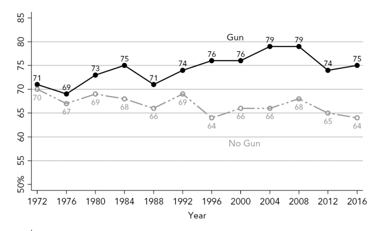

**Buenos Aires (2015–2023)**

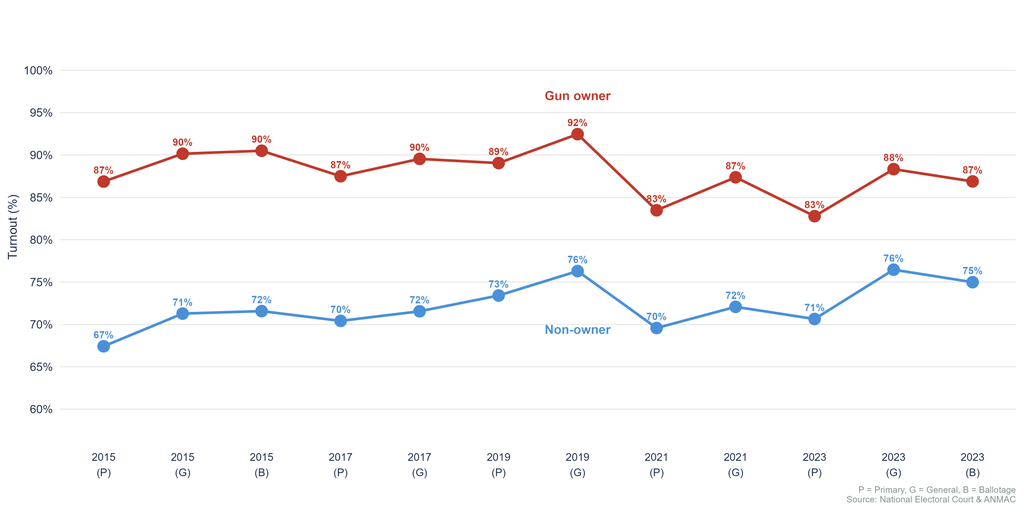

Left: Joslyn (2020), U.S. 1972–2016. Right: National Electoral Court & ANMAC, Buenos Aires 2015–2023.

## The Existing Literature Cannot Explain This

The usual explanations don’t apply here

Second Amendment culture & constitutional identity (Shapira & Simon, 2018; Lacombe et al., 2024)

✗ Argentina has no Second Amendment

Organised gun-rights lobby (NRA-type groups) (Lacombe et al., 2024)

✗ No equivalent organisation in Argentina

Collective political identity around gun ownership (Higginbotham, 2025; Buttrick, 2020)

✗ Gun owners don’t act as a political group

So what is driving this?

Every existing explanation requires either a **cultural identity** around guns or an **organizational infrastructure** that mobilizes owners collectively.

→ Argentina has neither.

## Where Do Gun Owners Live?

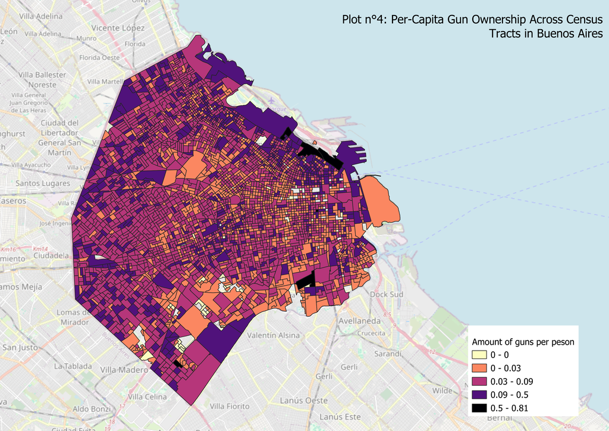

Per-capita gun ownership across census tracts in Buenos Aires

## Where Do Gun Owners Live?

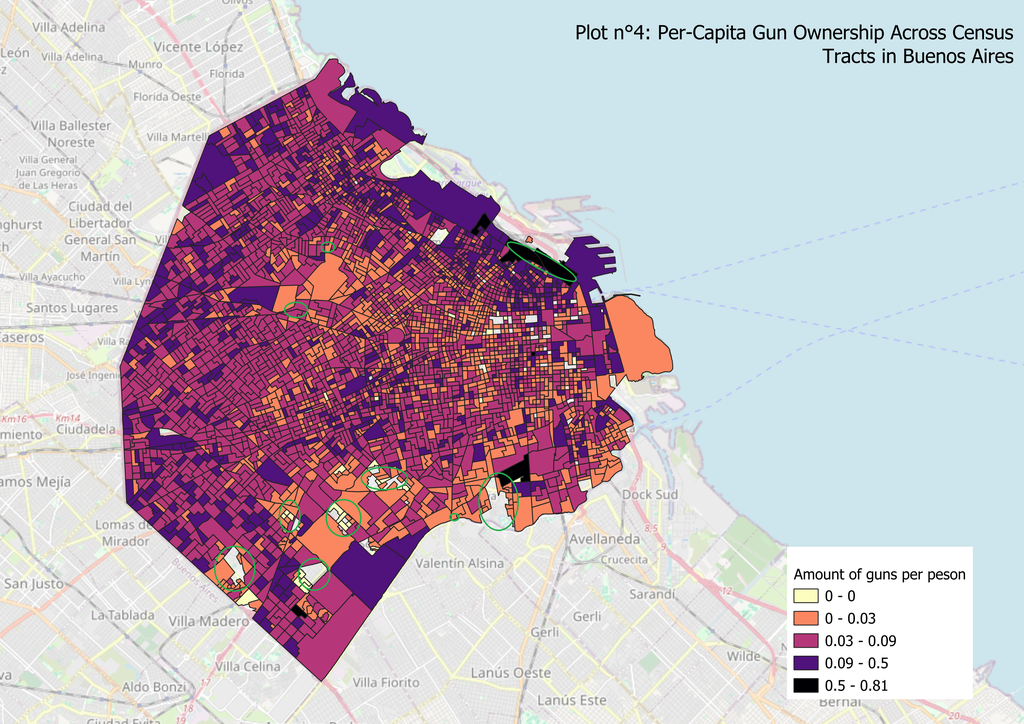

Per-capita gun ownership across census tracts in Buenos Aires

## The Mechanism

### 1. Substitution

Citizens do not delegate their security in the state anymore. They privatize their security (Kessler, 2009; Yashar, 2018)

→

### 2. The Paradox

Although, the same citizens who armed themselves in rejection of the state continue to vote, donate, and engage politically. Why would someone who replaced the state still invest in it? (Joslyn, 2020)

→

### 3. Engaged Toleration

They participate because of strategic tolerance: enough engagement to keep the state functional, no more. (Holland, 2017; Levi, 1988)

## Inverted Forbearance

#### Holland’s Forbearance (2017)

**State → Citizens**

- When the state cannot or will not enforce its own rules, it tolerates non-compliance rather than confronting it, preserving the relationship at the cost of enforcement

Brinks et al. (2020)

**Result:** Ongoing institutional relationship maintained through strategic non-enforcement

⇄

#### Inverted Forbearance

**Citizens → State**

- Gun owners do not abandon the state politically because they still believe in a **minimal version of it**, one that maintains basic order, even if it failed at security. They tolerate the gap between the state they have and the state they want.

**Result:** Stable participation, without enthusiasm, not exit. Citizens engaging with a state they have partially replaced but not fully rejected.

## Research Design

### Design Logic

**Running variable**  
Signed distance to the administrative boundary of the nearest *barrio popular*/villa  
(inside < 0, outside > 0)

**Cutoff**  
The official administrative limit

### Outcomes

**Primary:** Gun ownership rate per census tract

**Secondary:** Turnout · Donations · Hearing attendance

## Limitations and next steps:

1. Data Collection in villas but also at Camara Nacional Electoral
2. Does “inverted forbearance” the best term to describe an increase in participation modest?
3. There are ongoing projects to continue study the relationship between the state and gun owners:
1. Working paper Gonzalez & Visconti (2026)]
2. Natural Experiment on Historical Legacies with Sebastian Cortesi.
3. Interviews with Gun Owners soon in Argentina!

## References

Brinks, D., Levitsky, S., & Murillo, M. V. (2020). *The politics of institutional weakness in latin america*. Cambridge University Press.

Gonzalez, G., & Visconti, G. (2026). *Exit without voice: Crime shocks and the erosion of citizen-state relations in argentina* [Unpublished manuscript].

Hirschman, A. O. (1972). *Exit, voice, and loyalty: Responses to decline in firms, organizations, and states*. Harvard University Press.

Holland, A. C. (2017). *Forbearance as redistribution: The politics of informal welfare in latin america*. Cambridge University Press.

Joslyn, M. R. (2020). The gun gap: The influence of gun ownership on political behavior and attitudes. *Political Behavior*, *42*, 1235–1257.

Kessler, G. (2009). *El sentimiento de inseguridad: Sociología del temor al delito*. Siglo XXI Editores.

Levi, M. (1988). *Of rule and revenue*. University of California Press.

Yashar, D. J. (2018). *Homicidal ecologies: Illicit economies and complicit states in latin america*. Cambridge University Press.

## Preliminary Evidence

**Donation Distribution**

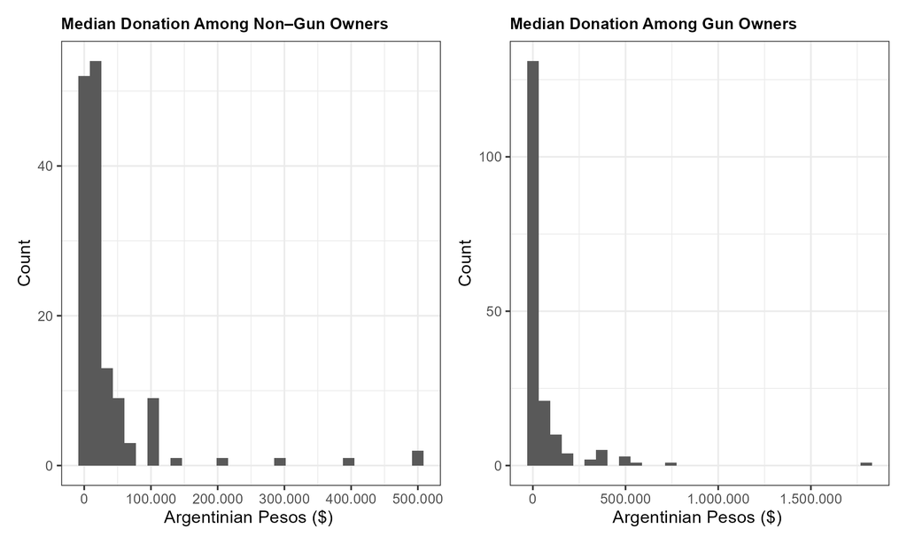

**Effect of Gun Ownership on Turnout (DiD)**

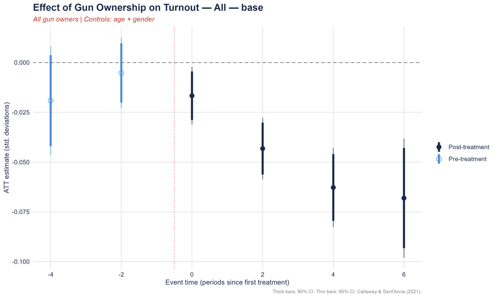

## The Puzzle

### What Theory Predicts

**Citizens who privatize security should exit**

(Hirschman, 1972): when private substitutes exist, citizens disengage from the state

- **Less voting, less donating, less engagement**

$\neq$

### What We Actually See

**Gun owners participate more, not less**

This is the puzzle this paper solves.

GVPT888P — Comparative Political Institutions | Final Presentation